# Homework 5

Mike Kozlowski

2023-02-27

van der Loo & de Jonge exercises for HW5

4.4.1:

Here, I tried several different ways of trying to do this, but ended up creating a loop to iterate over a vector based on the index of the vector to either add 2% or subtract 1% depending on if the index of the vector was odd or even. This does not return the expected results in terms of the output, and I’m not sure why. I likely have something messed up in the creation of my time-series object, but I can’t figure it out. It seems to be working properly, but I’m not sure why the initial value for January 1990 is 100.98. Also, this would have been simpler using a for loop, but the for loop did not operate as expected. The index in “for (i in data)” never incremented. I printed out i as it looped and i remained 0. So, I have no idea why that would be, but because of that, I was unable to use i to do a similar operation within a simpler for loop.

```r
data <- rep(0, 120)
entry <- 100
count <- 121
runner <- 0

while (count >= 0) {
  if (runner %% 2 == 0) {
    entry <- entry * 1.02
    data[runner] <- entry
    runner <- runner + 1
    count <- count - 1
  } else {
    entry <- entry - (entry * 0.01)
    data[runner] <- entry
    runner <- runner + 1
    count <- count - 1
  }
}

nineties <- ts(data = data, start = 1990, end = 2000, frequency = 12)
nineties
```

```
##           Jan      Feb      Mar      Apr      May      Jun      Jul      Aug
## 1990 100.9800 102.9996 101.9696 104.0090 102.9689 105.0283 103.9780 106.0576
## 1991 107.0650 109.2063 108.1142 110.2765 109.1738 111.3572 110.2437 112.4485
## 1992 113.5167 115.7870 114.6292 116.9217 115.7525 118.0676 116.8869 119.2246
## 1993 120.3572 122.7643 121.5367 123.9674 122.7277 125.1823 123.9305 126.4091
## 1994 127.6098 130.1620 128.8604 131.4376 130.1232 132.7257 131.3985 134.0264
## 1995 135.2996 138.0055 136.6255 139.3580 137.9644 140.7237 139.3165 142.1028
## 1996 143.4526 146.3217 144.8585 147.7556 146.2781 149.2037 147.7116 150.6659
## 1997 152.0970 155.1390 153.5876 156.6593 155.0927 158.1946 156.6127 159.7449
## 1998 161.2623 164.4876 162.8427 166.0996 164.4386 167.7273 166.0501 169.3711
## 1999 170.9799 174.3995 172.6555 176.1086 174.3476 177.8345 176.0562 179.5773
## 2000 181.2831
##           Sep      Oct      Nov      Dec
## 1990 104.9970 107.0969 106.0260 108.1465
## 1991 111.3241 113.5505 112.4150 114.6633
## 1992 118.0324 120.3930 119.1891 121.5729
## 1993 125.1450 127.6479 126.3714 128.8988
## 1994 132.6862 135.3399 133.9865 136.6662
## 1995 140.6818 143.4954 142.0605 144.9017
## 1996 149.1592 152.1424 150.6210 153.6334
## 1997 158.1475 161.3104 159.6973 162.8913
## 1998 167.6774 171.0309 169.3206 172.7070
## 1999 177.7815 181.3372 179.5238 183.1143
## 2000
```

4.4.2:

Took me quite a bit of research to figure out how to get these simple commands up and running.

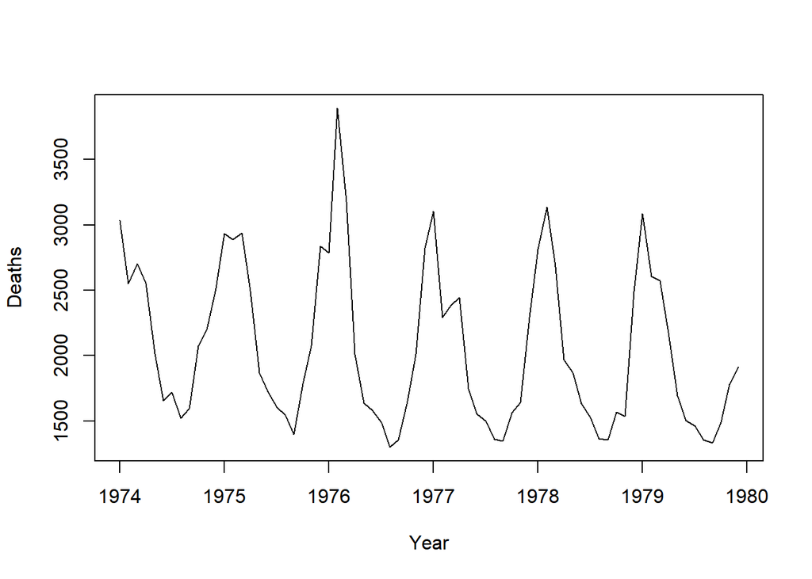

```r
plot(ldeaths, xlab = "Year", ylab = "Deaths")
```

```r
mymts <- ts(ts.union(fdeaths, mdeaths), start = 1974, end = c(1979, 12), frequency = 12)
class(mymts)
```

```
## [1] "mts"    "ts"     "matrix"
```

```r
mymts
```

```
##          fdeaths mdeaths
## Jan 1974     901    2134
## Feb 1974     689    1863
## Mar 1974     827    1877
## Apr 1974     677    1877
## May 1974     522    1492
## Jun 1974     406    1249
## Jul 1974     441    1280
## Aug 1974     393    1131
## Sep 1974     387    1209
## Oct 1974     582    1492
## Nov 1974     578    1621
## Dec 1974     666    1846
## Jan 1975     830    2103
## Feb 1975     752    2137
## Mar 1975     785    2153
## Apr 1975     664    1833
## May 1975     467    1403
## Jun 1975     438    1288
## Jul 1975     421    1186
## Aug 1975     412    1133
## Sep 1975     343    1053
## Oct 1975     440    1347
## Nov 1975     531    1545
## Dec 1975     771    2066
## Jan 1976     767    2020
## Feb 1976    1141    2750
## Mar 1976     896    2283
## Apr 1976     532    1479
## May 1976     447    1189
## Jun 1976     420    1160
## Jul 1976     376    1113
## Aug 1976     330     970
## Sep 1976     357     999
## Oct 1976     445    1208
## Nov 1976     546    1467
## Dec 1976     764    2059
## Jan 1977     862    2240
## Feb 1977     660    1634
## Mar 1977     663    1722
```

[output cut: 18 more lines]

```
## Oct 1978     430    1140
## Nov 1978     425    1110
## Dec 1978     679    1812
## Jan 1979     821    2263
## Feb 1979     785    1820
## Mar 1979     727    1846
## Apr 1979     612    1531
## May 1979     478    1215
## Jun 1979     429    1075
## Jul 1979     405    1056
## Aug 1979     379     975
## Sep 1979     393     940
## Oct 1979     411    1081
## Nov 1979     487    1294
## Dec 1979     574    1341
```